# CS 1675 Final Project: Part 2A

Regression Models

Anastasia Sosnovskikh

## Load packages

Load the packages used for EDA.

```r
library(tidyverse)
```

```r
library(dplyr)
library(ggplot2)
library(caret)
library(coefplot)
```

## Load Data

Read in the data.

```r
data_url <- 'https://raw.githubusercontent.com/jyurko/CS_1675_Fall_2020/master/HW/final_project/cs_1675_final_project_data.csv'

df_raw <- readr::read_csv(data_url, col_names = TRUE)
```

Separate the variables associated with Step 1.

```r
df_step1_inputs <- df_raw %>% select(xA, xB, x01:x06, response_1)
```

Separate the variables associated with the Option B classification formulation. The `outcome_2` variable is converted to a factor with a specific ordering of the levels. This ordering is used when modeling in `caret` to make sure everyone predicts the `Fail` class as the “positive” class in the confusion matrix.

```r
df_step2_B_inputs <- df_raw %>% select(xA, xB, response_1, x07:x11, outcome_2) %>%
  mutate(outcome_2 = factor(outcome_2, levels = c('Fail', 'Pass')))
```

Separate the variables associated with the Option A classification formulation. The `outcome_2` variable is again converted to a factor with a specific ordering of the levels.

```r
df_step2_A_inputs <- df_raw %>% select(xA, xB, x01:x11, outcome_2) %>%
  mutate(outcome_2 = factor(outcome_2, levels = c('Fail', 'Pass')))
```

Change data types for the whole data frame to perform EDA.

```r
df <- df_raw %>%
  mutate(xA = as.factor(xA),
         xB = as.factor(xB),
         outcome_2 = factor(outcome_2, levels = c('Fail', 'Pass')))
```

Standardize the data.

```r
get_standardized <- function(df) {
  predict(preProcess(df, method = c('center', 'scale')), df)
}

df_step1_inputs_stand <- df_step1_inputs %>%  get_standardized()
df_step2_A_inputs_stand <- df_step2_A_inputs %>% get_standardized()
df_step2_B_inputs_stand <- df_step2_B_inputs %>%  get_standardized()
df_stand <- df %>% get_standardized()
```

Some helper functions to get the features of a particular type.

```r
get_CATEGORICAL_features_list <- function(df){
  colnames(df)[grepl('factor|logical|character',sapply(df,class))]
}
```

```r
get_CONTINIOUS_features_list <- function(df){
  df %>% select(-get_CATEGORICAL_features_list(df)) %>% colnames()
}
```

## Helpful functions

Visualize the coefficients

```r
show_coef <- function(mod_obj){
  mod_obj %>%
    coefplot::coefplot() +
    theme_bw()
}
```

Extract Metrics

```r
extract_metrics <- function(mod_obj, mod_name)
{
  broom::glance(mod_obj) %>%
    mutate(model_name = mod_name)
}
```

## Fit Linear Models

Fit linear models for `response_1` with the inputs from **Step 1**.

### 1.Just the discrete inputs – additive terms.

Fit the model with `lm()`.

```r
mod_lm_categorical <- lm(response_1 ~ xA + xB, df_step1_inputs_stand)
```

Summarize the model results with the `summary()` function.

```r
mod_lm_categorical %>% summary()
```

```
##
## Call:
## lm(formula = response_1 ~ xA + xB, data = df_step1_inputs_stand)
##
## Residuals:
##     Min      1Q  Median      3Q     Max
## -4.8472 -0.4823 -0.0395  0.4995  4.8450
##
## Coefficients:
##             Estimate Std. Error t value Pr(>|t|)
## (Intercept)  0.53197    0.04488  11.853  < 2e-16 ***
## xAA2         0.06337    0.03794   1.670    0.095 .
## xBB2        -0.45694    0.05227  -8.743  < 2e-16 ***
## xBB3        -1.42593    0.05329 -26.759  < 2e-16 ***
## xBB4        -0.26098    0.05634  -4.632 3.85e-06 ***
## ---
## Signif. codes:  0 '***' 0.001 '**' 0.01 '*' 0.05 '.' 0.1 ' ' 1
##
## Residual standard error: 0.8402 on 2008 degrees of freedom
## Multiple R-squared:  0.2954, Adjusted R-squared:  0.294
## F-statistic: 210.5 on 4 and 2008 DF,  p-value: < 2.2e-16
```

Visualize the coefficients.

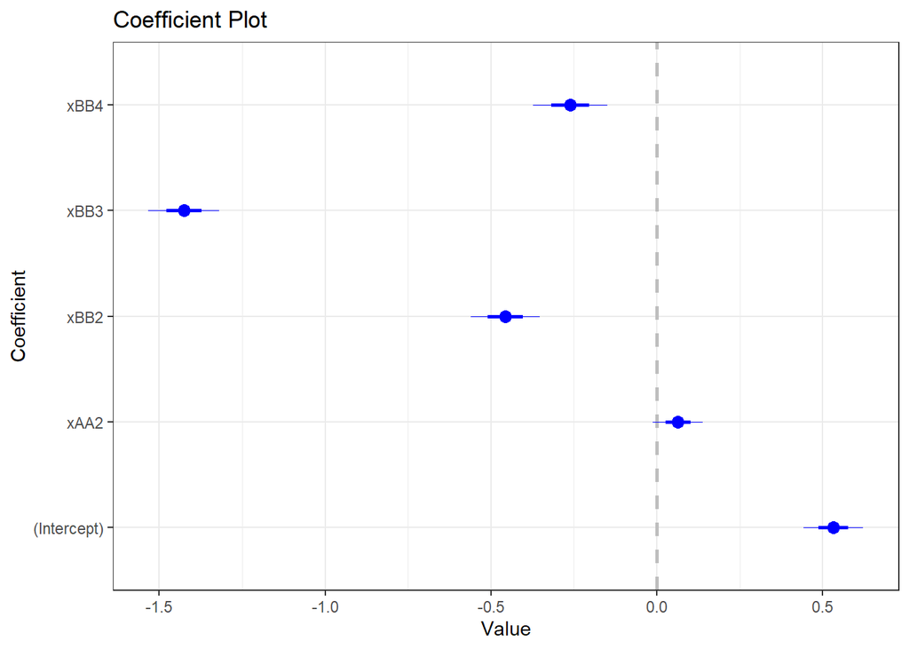

```r
mod_lm_categorical %>%  show_coef()
```

Extract metrics.

```r
extract_metrics(mod_obj = mod_lm_categorical, mod_name = 'mod_lm_categorical')
```

```
## # A tibble: 1 x 13
##   r.squared adj.r.squared sigma statistic   p.value    df logLik   AIC   BIC
##       <dbl>         <dbl> <dbl>     <dbl>     <dbl> <dbl>  <dbl> <dbl> <dbl>
## 1     0.295         0.294 0.840      210. 6.41e-151     4 -2503. 5019. 5052.
## # ... with 4 more variables: deviance <dbl>, df.residual <int>, nobs <int>,
## #   model_name <chr>
```

### 2. Just the continuous inputs – additive terms.

Fit the model with `lm()`.

```r
mod_lm_continious <- lm(response_1 ~ x01 + x02 + x03 + x04 + x05 + x06, df_step1_inputs_stand)
```

Summarize the model results with the `summary()` function.

```r
mod_lm_continious %>% summary()
```

```
##
## Call:
## lm(formula = response_1 ~ x01 + x02 + x03 + x04 + x05 + x06,
##     data = df_step1_inputs_stand)
##
## Residuals:
##     Min      1Q  Median      3Q     Max
## -4.7909 -0.3925  0.0046  0.4122  4.1677
##
## Coefficients:
##               Estimate Std. Error t value Pr(>|t|)
## (Intercept)  3.671e-16  1.996e-02   0.000   1.0000
## x01          3.251e-01  2.010e-02  16.174  < 2e-16 ***
## x02         -3.025e-01  2.005e-02 -15.090  < 2e-16 ***
## x03          8.460e-02  2.008e-02   4.212 2.64e-05 ***
## x04          4.029e-02  2.008e-02   2.006   0.0450 *
## x05          4.996e-02  2.004e-02   2.493   0.0127 *
## x06          2.230e-02  2.008e-02   1.111   0.2669
## ---
## Signif. codes:  0 '***' 0.001 '**' 0.01 '*' 0.05 '.' 0.1 ' ' 1
##
## Residual standard error: 0.8956 on 2006 degrees of freedom
## Multiple R-squared:  0.2003, Adjusted R-squared:  0.1979
## F-statistic: 83.75 on 6 and 2006 DF,  p-value: < 2.2e-16
```

Visualize the coefficients.

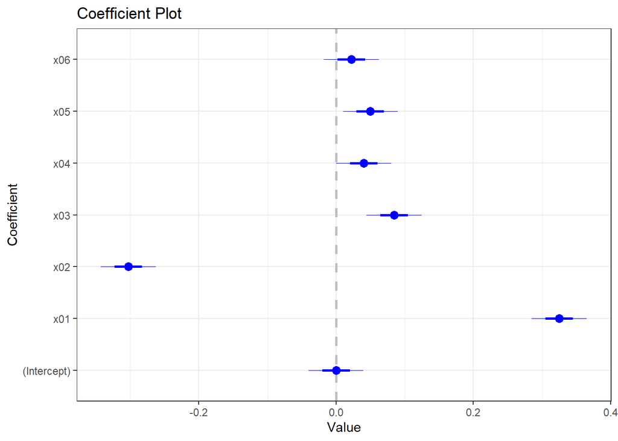

```r
mod_lm_continious %>%  show_coef()
```

Extract metrics.

```r
extract_metrics(mod_obj = mod_lm_continious, mod_name = 'mod_lm_continious')
```

```
## # A tibble: 1 x 13
##   r.squared adj.r.squared sigma statistic  p.value    df logLik   AIC   BIC
##       <dbl>         <dbl> <dbl>     <dbl>    <dbl> <dbl>  <dbl> <dbl> <dbl>
## 1     0.200         0.198 0.896      83.8 8.60e-94     6 -2631. 5278. 5323.
## # ... with 4 more variables: deviance <dbl>, df.residual <int>, nobs <int>,
## #   model_name <chr>
```

### 3. All step 1 inputs – additive terms.

Fit the model with `lm()`.

```r
mod_lm_all <- lm(response_1 ~ x01 + x02 + x03 + x04 + x05 + x06 + xA + xB, df_step1_inputs_stand)
```

Summarize the model results with the `summary()` function.

```r
mod_lm_all %>% summary()
```

```
##
## Call:
## lm(formula = response_1 ~ x01 + x02 + x03 + x04 + x05 + x06 +
##     xA + xB, data = df_step1_inputs_stand)
##
## Residuals:
##     Min      1Q  Median      3Q     Max
## -4.0481 -0.3972 -0.0308  0.3869  3.5999
##
## Coefficients:
##              Estimate Std. Error t value Pr(>|t|)
## (Intercept)  0.521443   0.038826  13.430  < 2e-16 ***
## x01          0.274688   0.016258  16.895  < 2e-16 ***
## x02         -0.372295   0.016321 -22.811  < 2e-16 ***
## x03          0.035693   0.016293   2.191   0.0286 *
## x04          0.019350   0.016200   1.194   0.2324
## x05         -0.003949   0.016274  -0.243   0.8083
## x06         -0.010734   0.016292  -0.659   0.5101
## xAA2         0.079972   0.032141   2.488   0.0129 *
## xBB2        -0.445411   0.046975  -9.482  < 2e-16 ***
## xBB3        -1.455420   0.045219 -32.186  < 2e-16 ***
## xBB4        -0.235481   0.050795  -4.636 3.78e-06 ***
## ---
## Signif. codes:  0 '***' 0.001 '**' 0.01 '*' 0.05 '.' 0.1 ' ' 1
##
## Residual standard error: 0.7108 on 2002 degrees of freedom
## Multiple R-squared:  0.4973, Adjusted R-squared:  0.4948
## F-statistic:   198 on 10 and 2002 DF,  p-value: < 2.2e-16
```

Visualize the coefficients.

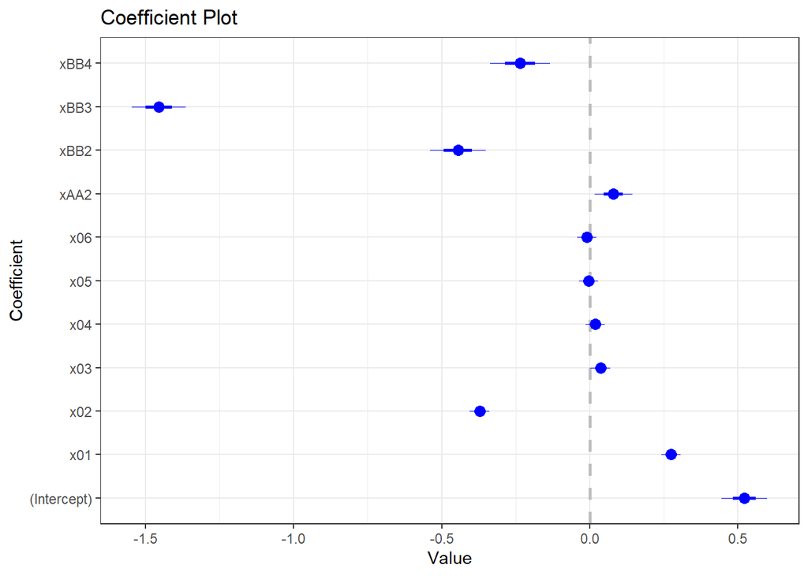

```r
mod_lm_all %>%  show_coef()
```

Extract metrics.

```r
extract_metrics(mod_obj = mod_lm_all, mod_name = 'mod_lm_all')
```

```
## # A tibble: 1 x 13
##   r.squared adj.r.squared sigma statistic   p.value    df logLik   AIC   BIC
##       <dbl>         <dbl> <dbl>     <dbl>     <dbl> <dbl>  <dbl> <dbl> <dbl>
## 1     0.497         0.495 0.711      198. 2.85e-290    10 -2164. 4351. 4419.
## # ... with 4 more variables: deviance <dbl>, df.residual <int>, nobs <int>,
## #   model_name <chr>
```

### 4. A basis function of your choice.

Explain the choice.

*I decided NOT to include `xA` because I found it not to have a huge impact on `response_1` when performing EDA. However, `xB` seem to be important, so I will include it. The relationship is parabolic. Inputs `x01:x03` seem to impact `response_1` the most. Thus, I think that there is an interaction between `response_1` and `x01:x03` influenced by `xB`.*

Fit the model with `lm()`.

```r
mod_lm_basis <- lm(response_1 ~ (x01 + x02 + x03 + xB)^2, df_step1_inputs_stand)
```

Summarize the model results with the `summary()` function.

```r
mod_lm_basis %>% summary()
```

```
##
## Call:
## lm(formula = response_1 ~ (x01 + x02 + x03 + xB)^2, data = df_step1_inputs_stand)
##
## Residuals:
##     Min      1Q  Median      3Q     Max
## -4.0776 -0.3852 -0.0396  0.3930  3.5335
##
## Coefficients:
##              Estimate Std. Error t value Pr(>|t|)
## (Intercept)  0.505309   0.032677  15.464  < 2e-16 ***
## x01          0.093749   0.032166   2.915 0.003602 **
## x02         -0.448104   0.031868 -14.061  < 2e-16 ***
## x03         -0.089248   0.032994  -2.705 0.006890 **
## xBB2        -0.382706   0.043971  -8.704  < 2e-16 ***
## xBB3        -1.277857   0.046034 -27.759  < 2e-16 ***
## xBB4        -0.174863   0.048439  -3.610 0.000314 ***
## x01:x02     -0.084817   0.016042  -5.287 1.38e-07 ***
## x01:x03      0.122820   0.015762   7.792 1.05e-14 ***
## x01:xBB2     0.094362   0.043425   2.173 0.029897 *
## x01:xBB3     0.412808   0.044265   9.326  < 2e-16 ***
## x01:xBB4     0.227579   0.046494   4.895 1.06e-06 ***
## x02:x03     -0.007681   0.016320  -0.471 0.637962
## x02:xBB2     0.141393   0.043981   3.215 0.001326 **
## x02:xBB3     0.140804   0.044268   3.181 0.001492 **
## x02:xBB4     0.022037   0.045557   0.484 0.628637
## x03:xBB2     0.104007   0.044137   2.356 0.018546 *
## x03:xBB3     0.266014   0.044198   6.019 2.09e-09 ***
## x03:xBB4     0.139982   0.047649   2.938 0.003344 **
## ---
## Signif. codes:  0 '***' 0.001 '**' 0.01 '*' 0.05 '.' 0.1 ' ' 1
##
## Residual standard error: 0.6728 on 1994 degrees of freedom
## Multiple R-squared:  0.5513, Adjusted R-squared:  0.5473
## F-statistic: 136.1 on 18 and 1994 DF,  p-value: < 2.2e-16
```

Visualize the coefficients.

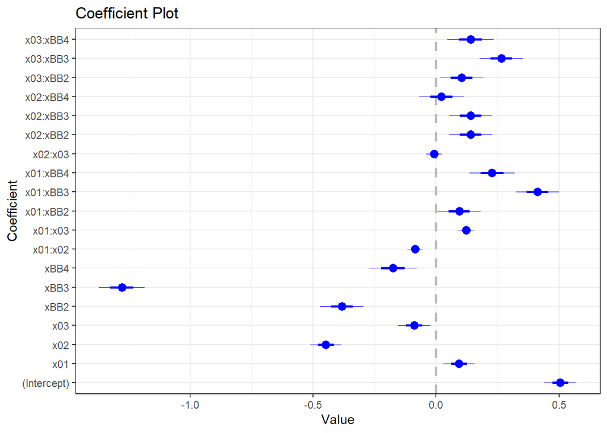

```r
mod_lm_basis %>%  show_coef()
```

Extract metrics.

```r
extract_metrics(mod_obj = mod_lm_basis, mod_name = 'mod_lm_basis')
```

```
## # A tibble: 1 x 13
##   r.squared adj.r.squared sigma statistic p.value    df logLik   AIC   BIC
##       <dbl>         <dbl> <dbl>     <dbl>   <dbl> <dbl>  <dbl> <dbl> <dbl>
## 1     0.551         0.547 0.673      136.       0    18 -2049. 4138. 4250.
## # ... with 4 more variables: deviance <dbl>, df.residual <int>, nobs <int>,
## #   model_name <chr>
```

## Assess Performance

### Get the data

Create a list of all the models.

```r
all_models <- list(mod_lm_categorical,
                   mod_lm_continious,
                   mod_lm_all,
                   mod_lm_basis)
```

Extract the performance metrics for all the models.

```r
model_names <- c('mod_lm_categorical',
                 'mod_lm_continious',
                 'mod_lm_all',
                 'mod_lm_basis')

all_model_metrics<- purrr::map2_dfr(all_models,
                                    model_names,
                                    extract_metrics)

all_model_metrics
```

```
## # A tibble: 4 x 13
##   r.squared adj.r.squared sigma statistic   p.value    df logLik   AIC   BIC
##       <dbl>         <dbl> <dbl>     <dbl>     <dbl> <dbl>  <dbl> <dbl> <dbl>
## 1     0.295         0.294 0.840     210.  6.41e-151     4 -2503. 5019. 5052.
## 2     0.200         0.198 0.896      83.8 8.60e- 94     6 -2631. 5278. 5323.
## 3     0.497         0.495 0.711     198.  2.85e-290    10 -2164. 4351. 4419.
## 4     0.551         0.547 0.673     136.  0.           18 -2049. 4138. 4250.
## # ... with 4 more variables: deviance <dbl>, df.residual <int>, nobs <int>,
## #   model_name <chr>
```

### Plot the `r-squared` and the `RMSE`

Since we are doing regression, the valid regression evaluation metrics are: R-Squared, MAE, and Root Mean Squared Error (`RMSE`).

I don’t want to use MAE because I want my performance metric to be consistent with how the coefficients are estimated in the first place.

Since the coefficients are estimated by minimizing the error, I am left with `RMSE` and `r-squared` as performance evaluation models for the regression problem I am trying to solve.

Note: R-Squared (ranges from 0 to 1) because it’s the worst one from the list. It doesn’t measure goodness of fit very well. It can be arbitrarily low when the model is completely correct and it can be arbitrarily close to 1 when the model is wrong (sources: HOML book, https://data.library.virginia.edu/is-r-squared-useless/, and https://www.rpubs.com/frycast/rsq).

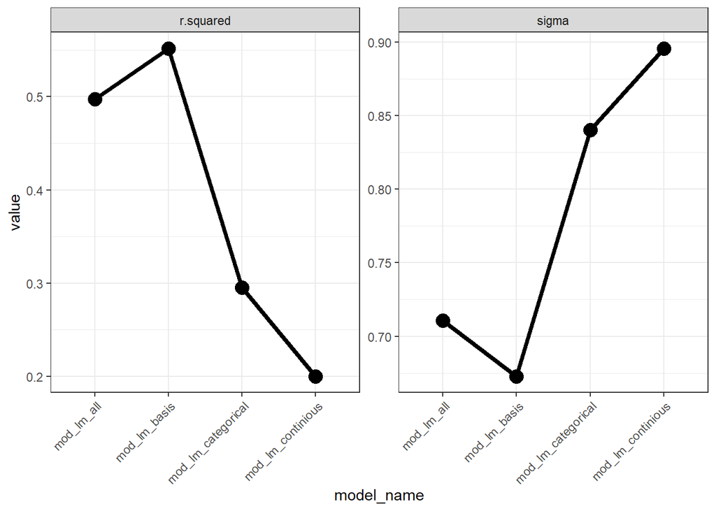

```r
all_model_metrics %>%
  dplyr::select(model_name, r.squared, sigma) %>%
  tidyr::gather(key = 'key', value = 'value', -model_name) %>%
  ggplot(mapping = aes(x = model_name, y = value)) +
  geom_line(size = 1.5,
            mapping = aes(group = key)) +
  geom_point(size = 4.5) +
  facet_wrap(~key, scales = 'free_y') +
  scale_x_discrete(guide = guide_axis(angle = 45)) +
  theme_bw()
```

*Based on the graphs, `mod_basis` - a basis function I came up with based on my analysis of EDA - seems to perform the best because this model has the highest `r-squared` and lowest `sigma`.*

### Plot `AIC` and `BIC`

*The Bayesian Information Criterion (`BIC`) penalizes the data fit, via the log-likelihood, based on the number of parameters. Thus, complex models with many parameters get penalized. Another metric called Akaike Information Criterion (`AIC`) does not penalize as strong as `BIC` but serves the same purpose. They both are better than `r-squared` and `RMSE` because they penalize complex models which may guard against overfitting.*

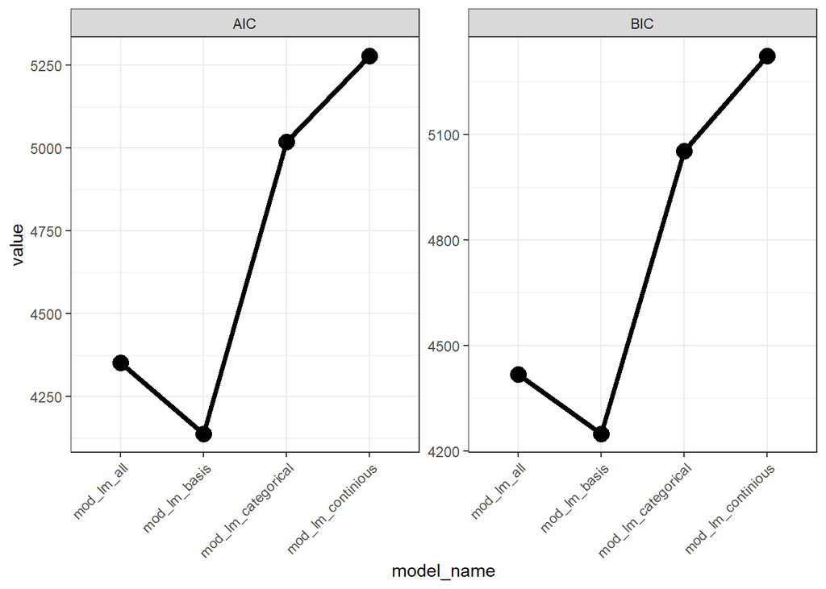

```r
all_model_metrics %>%
  dplyr::select(model_name, AIC, BIC) %>%
  tidyr::gather(key = 'key', value = 'value', - model_name) %>%
  ggplot(mapping = aes(x = model_name, y = value)) +
  geom_line(size = 1.5,
            mapping = aes(group = key)) +
  geom_point(size = 4.5) +
  facet_wrap(~ key, scales = 'free_y') +
  scale_x_discrete(guide = guide_axis(angle = 45)) +
  theme_bw()
```

*Based on the graphs, `mod_basis` - a basis function I came up with based on my analysis of EDA - seems to perform the best again because this model has the lowest `AIC` and `BIC`.*

##### Which of the 4 models is the best? What performance metric did you use to make your selection?

*`mod_basis` is the best model based on `r-squared`, `RMSE`, `AIC`, and `BIC`.*

## Visualize the coefficient summaries for best two models.

Visualize the coefficients for the best two models.

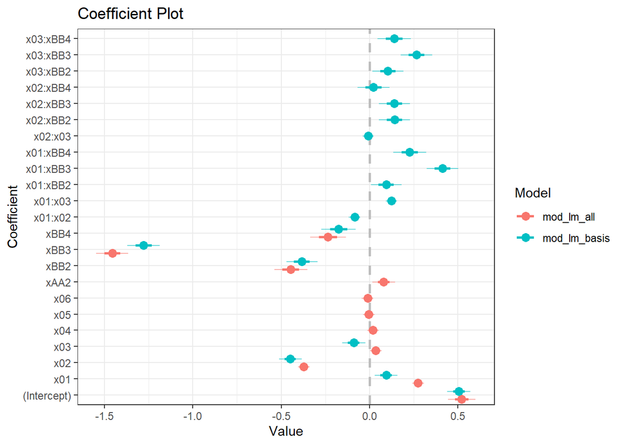

```r
coefplot::multiplot(mod_lm_all, mod_lm_basis) +
  theme_bw()
```

*The best two models are `mod_lm_all`, all step 1 inputs – additive terms, and `mod_lm_basis`, a basis function I came up with based on EDA.*

##### How do the coefficient summaries for best two models compare?

*Both graphs have identified the coefficients fot `x02`, `xBB2`, `xBB3`, and `xBB4` to be non-zero, so they impact the results. Since the `mod_lm_basis` is performing better than `mod_lm_all`, from this graph we can derive that **interactions** (the top part of the graph) are important for the model. Many of the unique coefficients for `mod_lm_all' are close to`0`, thus, unimportant for the result.*

## Save the best models

```r
mod_lm_all %>% readr::write_rds('mod_lm_all.rds')
```

```r
mod_lm_basis %>% readr::write_rds('mod_lm_basis.rds')
```